# Sacred values as index signals of trustworthy character — Reproducibility Pipeline (Studies 1 & 2)

## 3.11 Audit: computed vs paper (Study 1)

Reported values are declared here as targets, then compared with the numbers computed above; the per-item tables above display the SI-printed figure next to the computed one.

```r
s1_cor <- cor(s1_vars, use = "pairwise.complete.obs")
s1_audit <- dplyr::bind_rows(
  # main text
  audit_row("Sacred trust M",               s1_desc$trust_M[2],   86.5, 0.1, 1),
  audit_row("Non-sacred trust M",           s1_desc$trust_M[1],   56.4, 0.1, 1),
  audit_row("Mann-Whitney U (U_max)",       s1_mw$U_max,        17787, 1.0, 1),
  audit_row("Mann-Whitney Z",               s1_mw$absZ,         11.63, 0.1, 2),
  audit_row("Effect size r",                s1_mw$r,             0.69, 0.01, 2),
  audit_row("CLES / prob. superiority",     s1_pos,              0.90, 0.01, 2),
  audit_row("Trust scale alpha",            s1_alpha_trust,      0.93, 0.01),
  audit_row("Acceptance scale alpha",       s1_alpha_accept,     0.91, 0.01),
  audit_row("Low-sanctity subgroup U",      s1_mw_low$U_max,    322.5, 1.0, 1),
  audit_row("Low-sanctity subgroup Z",      s1_mw_low$absZ,      2.84, 0.1, 2),
  audit_row("Low-sanctity subgroup r",      s1_mw_low$r,         0.43, 0.02, 2),
  # SI: parametric composites
  audit_row("t trust composite",            s1_t_trust$t,       15.47, 0.1, 2),
  audit_row("d trust composite",            s1_t_trust$d,        1.84, 0.03, 2),
  audit_row("t interpersonal composite",    s1_t_accept$t,      13.16, 0.1, 2),
  audit_row("d interpersonal composite",    s1_t_accept$d,       1.56, 0.03, 2),
  # SI: without exclusions
  audit_row("No-excl MW trust U",           s1_mw_ne_tr$U_max,  19525, 1.0, 1),
  audit_row("No-excl MW trust Z",           s1_mw_ne_tr$absZ,   10.86, 0.1, 2),
  audit_row("No-excl MW trust r",           s1_mw_ne_tr$r,       0.63, 0.02, 2),
  audit_row("No-excl MW interp. U",         s1_mw_ne_acc$U_max, 18745, 1.0, 1),
  audit_row("No-excl MW interp. Z",         s1_mw_ne_acc$absZ,   9.84, 0.1, 2),
  # SI: selfishness
  audit_row("Selfishness MW U (U_min)",     s1_mw_self$U_min,    2542, 1.0, 1),
  audit_row("Selfishness MW Z",             s1_mw_self$absZ,    10.78, 0.1, 2),
  audit_row("Selfishness MW r",             s1_mw_self$r,        0.64, 0.02, 2),
  audit_row("Selfishness sacred n",         s1_mw_self$n2,        138, 0.1, 0),
  audit_row("Selfishness non-sacred n",     s1_mw_self$n1,        142, 0.1, 0),
  audit_row("Selfishness sacred mean rank", s1_mw_self$mean_rank2, 87.92, 0.01, 2),
  audit_row("Selfishness non-sac mean rank",s1_mw_self$mean_rank1, 191.60, 0.01, 2),
  audit_row("Selfishness sacred M",         s1_mw_self$M2,       9.28, 0.01, 2),
  audit_row("Selfishness sacred SD",        s1_mw_self$SD2,     16.28, 0.01, 2),
  audit_row("Selfishness non-sacred M",     s1_mw_self$M1,      43.98, 0.01, 2),
  audit_row("Selfishness non-sacred SD",    s1_mw_self$SD1,     27.18, 0.01, 2),
  audit_row("Med selfish->trust B",         s1_med_self_tr$indirect,  11.69, 0.5, 2),
  audit_row("Med selfish->interp B",        s1_med_self_acc$indirect, 14.63, 0.5, 2),
  audit_row("Dual: selfishness indirect",   s1_dual$est[["i1"]],  6.24, 0.5, 2),
  audit_row("Dual: trust indirect",         s1_dual$est[["i2"]], 21.42, 0.6, 2),
  audit_row("Dual: direct effect",          s1_dual$est[["dir"]], 5.02, 0.6, 2),
  # SI: intercorrelations
  audit_row("r(trust, interpersonal)",      s1_cor["Trust", "Interpersonal"],  0.79, 0.01, 2),
  audit_row("r(trust, selfishness)",        s1_cor["Trust", "Selfishness"],   -0.68, 0.01, 2)
)
kable(s1_audit, align = "lrrl")
```

| Quantity | Reported | Computed | Check |
| --- | --- | --- | --- |
| Sacred trust M | 86.5 | 86.5 | match |
| Non-sacred trust M | 56.4 | 56.4 | match |
| Mann-Whitney U (U_max) | 17787.0 | 17786.5 | match |
| Mann-Whitney Z | 11.63 | 11.63 | match |
| Effect size r | 0.69 | 0.69 | match |
| CLES / prob. superiority | 0.90 | 0.90 | match |
| Trust scale alpha | 0.93 | 0.93 | match |
| Acceptance scale alpha | 0.91 | 0.91 | match |
| Low-sanctity subgroup U | 322.5 | 322.5 | match |
| Low-sanctity subgroup Z | 2.84 | 2.84 | match |
| Low-sanctity subgroup r | 0.43 | 0.43 | match |
| t trust composite | 15.47 | 15.47 | match |
| d trust composite | 1.84 | 1.83 | match |
| t interpersonal composite | 13.16 | 13.16 | match |
| d interpersonal composite | 1.56 | 1.56 | match |
| No-excl MW trust U | 19525.0 | 19525.0 | match |
| No-excl MW trust Z | 10.86 | 10.86 | match |
| No-excl MW trust r | 0.63 | 0.63 | match |
| No-excl MW interp. U | 18745.0 | 18745.0 | match |
| No-excl MW interp. Z | 9.84 | 9.83 | match |
| Selfishness MW U (U_min) | 2542.0 | 2542.0 | match |
| Selfishness MW Z | 10.78 | 10.78 | match |
| Selfishness MW r | 0.64 | 0.64 | match |
| Selfishness sacred n | 138 | 138 | match |
| Selfishness non-sacred n | 142 | 142 | match |
| Selfishness sacred mean rank | 87.92 | 87.92 | match |
| Selfishness non-sac mean rank | 191.60 | 191.60 | match |
| Selfishness sacred M | 9.28 | 9.28 | match |
| Selfishness sacred SD | 16.28 | 16.28 | match |
| Selfishness non-sacred M | 43.98 | 43.98 | match |
| Selfishness non-sacred SD | 27.18 | 27.18 | match |
| Med selfish->trust B | 11.69 | 11.69 | match |
| Med selfish->interp B | 14.63 | 14.63 | match |
| Dual: selfishness indirect | 6.24 | 6.24 | match |
| Dual: trust indirect | 21.42 | 21.42 | match |
| Dual: direct effect | 5.02 | 5.02 | match |
| r(trust, interpersonal) | 0.79 | 0.79 | match |
| r(trust, selfishness) | -0.68 | -0.68 | match |

# 4 Study 2 — Pork Investment (out-group)

> *“Ahmed,”* a devout Muslim, refuses (sacred) or accepts (non-sacred) a lucrative but religiously forbidden investment. Non-Muslim raters only — an out-group commitment. Reported $N = 287$.

## 4.1 Load, exclude, and build measures

```r
s2 <- read_sav(s2_file)

# Pre-registered exclusions: keep Exclusions == 0 ("Good").
s2a <- s2 %>% filter(Exclusions == 0)

# Condition: Cond_01  (0 = non-sacred, 1 = sacred) per OSF variable key.
s2a$x    <- as.numeric(s2a$Cond_01)
s2a$cond <- factor(s2a$x, levels = c(0, 1),
                   labels = c("Non-sacred (accepted)", "Sacred (refused)"))

# Composites and single-item measures:
#   trust    = mean(Trust_Att_1..6) == Trust_At
#   accept   = mean(Rel_1..4)       == Int_Per
#   selfish  = Trust_Att_7
#   svfr     = SV_FR    (perceived sacralizing of close friendship)
#   mc       = MC_IOS   (perceived closeness to the Muslim community)
s2a$trust   <- composite(s2a, paste0("Trust_Att_", 1:6))
s2a$accept  <- composite(s2a, paste0("Rel_", 1:4))
s2a$selfish <- as.numeric(s2a$Trust_Att_7)
s2a$svfr    <- as.numeric(s2a$SV_FR)
s2a$mc      <- as.numeric(s2a$MC_IOS)

stopifnot("Study 2 N after exclusions != 287" = nrow(s2a) == 287L)
stopifnot(
  max(abs(s2a$trust  - s2a$Trust_At), na.rm = TRUE) < 1e-6,
  max(abs(s2a$accept - s2a$Int_Per),  na.rm = TRUE) < 1e-6
)

table(s2a$cond)
```

```
##
## Non-sacred (accepted)      Sacred (refused)
##                   146                   141
```

## 4.2 Scale reliability

```r
s2_alpha_trust  <- cronbach_alpha(s2a, paste0("Trust_Att_", 1:6))
s2_alpha_accept <- cronbach_alpha(s2a, paste0("Rel_", 1:4))
c(trust_alpha = round(s2_alpha_trust, 3), accept_alpha = round(s2_alpha_accept, 3))
```

```
##  trust_alpha accept_alpha
##        0.938        0.865
```

## 4.3 Descriptives by condition

```r
s2_desc <- s2a %>%
  group_by(Condition = cond) %>%
  summarise(n = n(),
            trust_M  = mean(trust),  trust_SD  = sd(trust),
            accept_M = mean(accept), accept_SD = sd(accept),
            .groups = "drop")
s2_desc
```

| Condition | n | trust_M | trust_SD | accept_M | accept_SD |
| --- | --- | --- | --- | --- | --- |
| Non-sacred (accepted) | 146 | 49.26256 | 22.57614 | 41.70548 | 24.89429 |
| Sacred (refused) | 141 | 81.46572 | 14.26403 | 62.48936 | 19.75237 |

## 4.4 Trustworthiness contrast (Mann-Whitney U) — *main text*

```r
s2_mw  <- mann_whitney(s2a$trust, s2a$cond)
s2_pos <- prob_superiority(s2a$trust[s2a$x == 1], s2a$trust[s2a$x == 0])

with(s2_mw, cat(sprintf(
  "U_max = %.1f (U_min = %.1f) | Z = %.2f | p = %.2e | r = %.2f | N = %d\n",
  U_max, U_min, absZ, p, r, N)))
```

```
## U_max = 18176.5 (U_min = 2409.5) | Z = 11.22 | p = 3.38e-29 | r = 0.66 | N = 287
```

```r
cat(sprintf("Probability of superiority / CLES (sacred > non-sacred) = %.3f\n", s2_pos))
```

```
## Probability of superiority / CLES (sacred > non-sacred) = 0.883
```

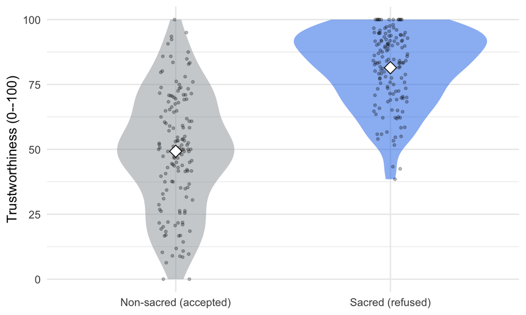

Study 2: distribution of trustworthiness ratings by condition. Diamonds mark condition means.

```r
ggplot(s2a, aes(cond, trust, fill = cond)) +
  geom_violin(alpha = 0.5, colour = NA, width = 0.9) +
  geom_jitter(width = 0.08, height = 0, alpha = 0.25, size = 0.9) +
  stat_summary(fun = mean, geom = "point", shape = 23, size = 4,
               fill = "white", colour = "black") +
  scale_fill_manual(values = c("#9aa0a6", "#1a73e8"), guide = "none") +
  labs(x = NULL, y = "Trustworthiness (0--100)") +
  theme_minimal(base_size = 13)
```

## 4.5 Normality assumption tests — *SI*

```r
s2_norm <- tibble(
  Variable = c("Trust attribution", "Interpersonal relationships",
               "Closeness to Muslim community"),
  W = c(shapiro.test(s2a$trust)$statistic, shapiro.test(s2a$accept)$statistic,
        shapiro.test(s2a$mc)$statistic),
  p = c(shapiro.test(s2a$trust)$p.value,   shapiro.test(s2a$accept)$p.value,
        shapiro.test(s2a$mc)$p.value),
  `SI W` = c(.95, .98, .83)
)
s2_norm %>% mutate(W = round(W, 3), p = signif(p, 3))
```

| Variable | W | p | SI W |
| --- | --- | --- | --- |
| Trust attribution | 0.949 | 0.000000 | 0.95 |
| Interpersonal relationships | 0.978 | 0.000206 | 0.98 |
| Closeness to Muslim community | 0.831 | 0.000000 | 0.83 |

## 4.6 Pre-registered parametric tests — *SI*

```r
s2_t_trust  <- welch_d(s2a$trust,  s2a$x)
s2_t_accept <- welch_d(s2a$accept, s2a$x)

cat(sprintf("Trust composite:          t(%.2f) = %.2f, p = %.2e, d = %.2f\n",
            s2_t_trust$df,  s2_t_trust$t,  s2_t_trust$p,  s2_t_trust$d))
```

```
## Trust composite:          t(246.10) = 14.50, p = 7.58e-35, d = 1.70
```

```r
cat(sprintf("Interpersonal composite:  t(%.2f) = %.2f, p = %.2e, d = %.2f  (M sacred = %.2f)\n",
            s2_t_accept$df, s2_t_accept$t, s2_t_accept$p, s2_t_accept$d, s2_t_accept$M1))
```

```
## Interpersonal composite:  t(274.74) = 7.85, p = 9.42e-14, d = 0.92  (M sacred = 62.49)
```

```r
item_table(
  s2a, paste0("Trust_Att_", 1:6),
  c("Committed", "Respectful", "Trustworthy", "Credible", "Reliable", "Benevolent"),
  si_t = c(15.89, 12.40, 12.69, 12.27, 11.98, 6.29),
  si_d = c(1.87,  1.46,  1.49,  1.44,  1.41,  0.74)
)
```

| Item | M sacred | M non-sac | t | df | d | SI t | SI d |
| --- | --- | --- | --- | --- | --- | --- | --- |
| Committed | 91.65 | 48.49 | 15.89 | 213.6 | 1.86 | 15.89 | 1.87 |
| Respectful | 84.41 | 51.18 | 12.40 | 248.1 | 1.45 | 12.40 | 1.46 |
| Trustworthy | 82.51 | 49.08 | 12.69 | 248.9 | 1.49 | 12.69 | 1.49 |
| Credible | 82.94 | 49.62 | 12.27 | 249.2 | 1.44 | 12.27 | 1.44 |
| Reliable | 82.31 | 50.96 | 11.98 | 252.6 | 1.40 | 11.98 | 1.41 |
| Benevolent | 64.97 | 46.25 | 6.29 | 284.2 | 0.74 | 6.29 | 0.74 |

```r
item_table(
  s2a, paste0("Rel_", 1:4),
  c("Close friend", "Romantic partner", "Work colleague", "Boss/supervisor"),
  si_t = c(8.46, 2.67, 7.58, 7.79),
  si_d = c(0.99, 0.32, 0.89, 0.92)
)
```

| Item | M sacred | M non-sac | t | df | d | SI t | SI d |
| --- | --- | --- | --- | --- | --- | --- | --- |
| Close friend | 71.75 | 45.18 | 8.46 | 270.3 | 0.99 | 8.46 | 0.99 |
| Romantic partner | 31.88 | 22.36 | 2.67 | 269.3 | 0.32 | 2.67 | 0.32 |
| Work colleague | 77.59 | 55.88 | 7.58 | 257.7 | 0.89 | 7.58 | 0.89 |
| Boss/supervisor | 68.74 | 43.40 | 7.79 | 280.6 | 0.92 | 7.79 | 0.92 |

## 4.7 Main analysis without exclusions — *SI*

```r
s2f <- s2
s2f$x     <- as.numeric(s2f$Cond_01)
s2f$cond  <- factor(s2f$x, 0:1, c("Non-sacred", "Sacred"))
s2f$trust <- composite(s2f, paste0("Trust_Att_", 1:6))
s2f$accept<- composite(s2f, paste0("Rel_", 1:4))
s2f$svfr  <- as.numeric(s2f$SV_FR)
s2f$mc    <- as.numeric(s2f$MC_IOS)

s2_ne_tr   <- mann_whitney(s2f$trust,  s2f$cond)
s2_ne_acc  <- mann_whitney(s2f$accept, s2f$cond)
s2_ne_svfr <- mann_whitney(s2f$svfr,   s2f$cond)
s2_ne_mc   <- mann_whitney(s2f$mc,     s2f$cond)

cat(sprintf("Full N = %d\n", nrow(s2f)))
```

```
## Full N = 302
```

```r
cat(sprintf("MW trust:          U_max = %.1f | Z = %.2f | r = %.2f\n", s2_ne_tr$U_max,   s2_ne_tr$absZ,   s2_ne_tr$r))
```

```
## MW trust:          U_max = 19836.5 | Z = 11.12 | r = 0.64
```

```r
cat(sprintf("MW interpersonal:  U_max = %.1f | Z = %.2f | r = %.2f\n", s2_ne_acc$U_max,  s2_ne_acc$absZ,  s2_ne_acc$r))
```

```
## MW interpersonal:  U_max = 16582.5 | Z = 6.83 | r = 0.39
```

```r
cat(sprintf("MW sacralizing:    U_max = %.1f | Z = %.2f | r = %.2f\n", s2_ne_svfr$U_max, s2_ne_svfr$absZ, s2_ne_svfr$r))
```

```
## MW sacralizing:    U_max = 17963.5 | Z = 8.66 | r = 0.50
```

```r
cat(sprintf("MW community:      U_max = %.1f | Z = %.2f | r = %.2f\n", s2_ne_mc$U_max,   s2_ne_mc$absZ,   s2_ne_mc$r))
```

```
## MW community:      U_max = 19832.5 | Z = 11.54 | r = 0.66
```

```r
# Full SI sentence for the interpersonal contrast, per condition (SI: sacred M = 62.13,
# SD = 20.98, mean rank = 186.05, n = 150; non-sacred M = 41.84, SD = 25.22, mean
# rank = 117.40, n = 152).
with(s2_ne_acc, cat(sprintf(
  "  interpersonal sacred:     M = %.2f, SD = %.2f, mean rank = %.2f, n = %d\n  interpersonal non-sacred: M = %.2f, SD = %.2f, mean rank = %.2f, n = %d\n",
  M2, SD2, mean_rank2, n2, M1, SD1, mean_rank1, n1)))
```

```
##   interpersonal sacred:     M = 62.13, SD = 20.98, mean rank = 186.05, n = 150
##   interpersonal non-sacred: M = 41.84, SD = 25.22, mean rank = 117.40, n = 152
```

## 4.8 Exploratory analysis of selfishness — *SI*

```r
s2_mw_self <- mann_whitney(s2a$selfish, s2a$cond)
with(s2_mw_self, cat(sprintf(
  "Selfishness by condition: U_min = %.1f (U_max = %.1f) | Z = %.2f | r = %.2f | N = %d\n",
  U_min, U_max, Z, r * sign(Z), N)))
```

```
## Selfishness by condition: U_min = 3450.0 (U_max = 17136.0) | Z = 9.76 | r = 0.58 | N = 287
```

```r
s2_med_self_tr  <- mediation_m4(s2a$x, s2a$selfish, s2a$trust,  n_boot = 5000, seed = 2024)
s2_med_self_acc <- mediation_m4(s2a$x, s2a$selfish, s2a$accept, n_boot = 5000, seed = 2024)
cat(sprintf("cond -> selfishness -> trust:          indirect B = %.2f, 95%% CI [%.2f, %.2f]\n",
            s2_med_self_tr$indirect,  s2_med_self_tr$ci[1],  s2_med_self_tr$ci[2]))
```

```
## cond -> selfishness -> trust:          indirect B = 11.75, 95% CI [8.23, 15.91]
```

```r
cat(sprintf("cond -> selfishness -> interpersonal:  indirect B = %.2f, 95%% CI [%.2f, %.2f]\n",
            s2_med_self_acc$indirect, s2_med_self_acc$ci[1], s2_med_self_acc$ci[2]))
```

```
## cond -> selfishness -> interpersonal:  indirect B = 12.07, 95% CI [8.32, 16.74]
```

## 4.9 Sacralizing of friendship and closeness to community — *SI*

Two exploratory out-group effects. Closeness to the Muslim community is the effect cited in the main text (participants saw the sacred valuer as *closer* to his community).

```r
s2_mw_svfr <- mann_whitney(s2a$svfr, s2a$cond)
s2_mw_mc   <- mann_whitney(s2a$mc,   s2a$cond)

with(s2_mw_svfr, cat(sprintf(
  "Sacralizing friendship: U_max = %.1f | Z = %.2f | r = %.2f  (M sacred = %.2f, non-sacred = %.2f)\n",
  U_max, absZ, r, mean(s2a$svfr[s2a$x == 1], na.rm = TRUE), mean(s2a$svfr[s2a$x == 0], na.rm = TRUE))))
```

```
## Sacralizing friendship: U_max = 16455.5 | Z = 8.78 | r = 0.52  (M sacred = 5.18, non-sacred = 3.98)
```

```r
with(s2_mw_mc, cat(sprintf(
  "Community closeness:    U_max = %.1f | Z = %.2f | r = %.2f  (M sacred = %.2f, non-sacred = %.2f)\n",
  U_max, absZ, r, mean(s2a$mc[s2a$x == 1], na.rm = TRUE), mean(s2a$mc[s2a$x == 0], na.rm = TRUE))))
```

```
## Community closeness:    U_max = 17897.5 | Z = 11.25 | r = 0.66  (M sacred = 6.47, non-sacred = 3.96)
```

## 4.10 Intercorrelations among key variables — *SI*

```r
s2_vars <- s2a[, c("trust", "accept", "svfr", "mc", "selfish")]
colnames(s2_vars) <- c("Trust", "Interpersonal", "Sacr. friend", "Muslim comm.", "Selfishness")
round(cor(s2_vars, use = "pairwise.complete.obs"), 2)
```

```
##               Trust Interpersonal Sacr. friend Muslim comm. Selfishness
## Trust          1.00          0.74         0.59         0.71       -0.65
## Interpersonal  0.74          1.00         0.46         0.48       -0.53
## Sacr. friend   0.59          0.46         1.00         0.45       -0.47
## Muslim comm.   0.71          0.48         0.45         1.00       -0.58
## Selfishness   -0.65         -0.53        -0.47        -0.58        1.00
```

```r
tibble(Variable = colnames(s2_vars),
       Mean = round(colMeans(s2_vars, na.rm = TRUE), 2),
       SD   = round(apply(s2_vars, 2, sd, na.rm = TRUE), 2))
```

| Variable | Mean | SD |
| --- | --- | --- |
| Trust | 65.08 | 24.86 |
| Interpersonal | 51.92 | 24.77 |
| Sacr. friend | 4.57 | 1.17 |
| Muslim comm. | 5.19 | 1.95 |
| Selfishness | 35.07 | 30.83 |

## 4.11 Audit: computed vs paper (Study 2)

```r
s2_cor <- cor(s2_vars, use = "pairwise.complete.obs")
s2_audit <- dplyr::bind_rows(
  # main text
  audit_row("Sacred trust M",               s2_desc$trust_M[2],   81.5, 0.1, 1),
  audit_row("Non-sacred trust M",           s2_desc$trust_M[1],   49.3, 0.1, 1),
  audit_row("Mann-Whitney U (U_max)",       s2_mw$U_max,        18177, 1.0, 1),
  audit_row("Mann-Whitney Z",               s2_mw$absZ,         11.22, 0.1, 2),
  audit_row("Effect size r",                s2_mw$r,             0.66, 0.01, 2),
  audit_row("CLES / prob. superiority",     s2_pos,              0.88, 0.01, 2),
  # SI: parametric composites
  audit_row("t trust composite",            s2_t_trust$t,       14.50, 0.1, 2),
  audit_row("d trust composite",            s2_t_trust$d,        1.71, 0.03, 2),
  audit_row("t interpersonal composite",    s2_t_accept$t,       7.85, 0.1, 2),
  audit_row("d interpersonal composite",    s2_t_accept$d,       0.92, 0.03, 2),
  audit_row("Interpersonal M sacred",        s2_t_accept$M1,   62.49, 0.1, 2),
  # SI: without exclusions
  audit_row("No-excl MW trust U",           s2_ne_tr$U_max,   19836.5, 1.0, 1),
  audit_row("No-excl MW trust Z",           s2_ne_tr$absZ,      11.12, 0.1, 2),
  audit_row("No-excl MW interp. U",         s2_ne_acc$U_max,  16582.5, 1.0, 1),
  audit_row("No-excl MW interp. Z",         s2_ne_acc$absZ,      6.83, 0.1, 2),
  audit_row("No-excl MW interp. r",         s2_ne_acc$r,         0.39, 0.02, 2),
  audit_row("No-excl interp. sacred M",     s2_ne_acc$M2,       62.13, 0.01, 2),
  audit_row("No-excl interp. sacred SD",    s2_ne_acc$SD2,      20.98, 0.01, 2),
  audit_row("No-excl interp. sacred rank",  s2_ne_acc$mean_rank2, 186.05, 0.01, 2),
  audit_row("No-excl interp. sacred n",     s2_ne_acc$n2,         150, 0.1, 0),
  audit_row("No-excl interp. non-sac M",    s2_ne_acc$M1,       41.84, 0.01, 2),
  audit_row("No-excl interp. non-sac SD",   s2_ne_acc$SD1,      25.22, 0.01, 2),
  audit_row("No-excl interp. non-sac rank", s2_ne_acc$mean_rank1, 117.40, 0.01, 2),
  audit_row("No-excl interp. non-sac n",    s2_ne_acc$n1,         152, 0.1, 0),
  audit_row("No-excl MW sacralizing U",     s2_ne_svfr$U_max, 17963.5, 1.0, 1),
  audit_row("No-excl MW community U",       s2_ne_mc$U_max,   19832.5, 1.0, 1),
  # SI: selfishness
  audit_row("Selfishness MW U (U_min)",     s2_mw_self$U_min,    3450, 1.0, 1),
  audit_row("Selfishness MW Z",             s2_mw_self$absZ,     9.76, 0.1, 2),
  audit_row("Selfishness MW r",             s2_mw_self$r,        0.58, 0.02, 2),
  audit_row("Med selfish->trust B",         s2_med_self_tr$indirect,  11.75, 0.5, 2),
  audit_row("Med selfish->interp B",        s2_med_self_acc$indirect, 12.07, 0.5, 2),
  # SI: sacralizing / community (excluded sample) + intercorrelations
  audit_row("Sacralizing friend U (U_max)", s2_mw_svfr$U_max, 16455.5, 1.0, 1),
  audit_row("Sacralizing friend r",         s2_mw_svfr$r,        0.52, 0.02, 2),
  audit_row("Community closeness U (U_max)",s2_mw_mc$U_max,   17897.5, 1.0, 1),
  audit_row("Community closeness r",        s2_mw_mc$r,          0.66, 0.02, 2),
  audit_row("r(trust, interpersonal)",      s2_cor["Trust", "Interpersonal"], 0.74, 0.01, 2),
  audit_row("r(trust, Muslim comm.)",       s2_cor["Trust", "Muslim comm."],  0.71, 0.01, 2)
)
kable(s2_audit, align = "lrrl")
```

| Quantity | Reported | Computed | Check |
| --- | --- | --- | --- |
| Sacred trust M | 81.5 | 81.5 | match |
| Non-sacred trust M | 49.3 | 49.3 | match |
| Mann-Whitney U (U_max) | 18177.0 | 18176.5 | match |
| Mann-Whitney Z | 11.22 | 11.22 | match |
| Effect size r | 0.66 | 0.66 | match |
| CLES / prob. superiority | 0.88 | 0.88 | match |
| t trust composite | 14.50 | 14.50 | match |
| d trust composite | 1.71 | 1.70 | match |
| t interpersonal composite | 7.85 | 7.85 | match |
| d interpersonal composite | 0.92 | 0.92 | match |
| Interpersonal M sacred | 62.49 | 62.49 | match |
| No-excl MW trust U | 19836.5 | 19836.5 | match |
| No-excl MW trust Z | 11.12 | 11.12 | match |
| No-excl MW interp. U | 16582.5 | 16582.5 | match |
| No-excl MW interp. Z | 6.83 | 6.83 | match |
| No-excl MW interp. r | 0.39 | 0.39 | match |
| No-excl interp. sacred M | 62.13 | 62.13 | match |
| No-excl interp. sacred SD | 20.98 | 20.98 | match |
| No-excl interp. sacred rank | 186.05 | 186.05 | match |
| No-excl interp. sacred n | 150 | 150 | match |
| No-excl interp. non-sac M | 41.84 | 41.84 | match |
| No-excl interp. non-sac SD | 25.22 | 25.22 | match |
| No-excl interp. non-sac rank | 117.40 | 117.40 | match |
| No-excl interp. non-sac n | 152 | 152 | match |
| No-excl MW sacralizing U | 17963.5 | 17963.5 | match |
| No-excl MW community U | 19832.5 | 19832.5 | match |
| Selfishness MW U (U_min) | 3450.0 | 3450.0 | match |
| Selfishness MW Z | 9.76 | 9.76 | match |
| Selfishness MW r | 0.58 | 0.58 | match |
| Med selfish->trust B | 11.75 | 11.75 | match |
| Med selfish->interp B | 12.07 | 12.07 | match |
| Sacralizing friend U (U_max) | 16455.5 | 16455.5 | match |
| Sacralizing friend r | 0.52 | 0.52 | match |
| Community closeness U (U_max) | 17897.5 | 17897.5 | match |
| Community closeness r | 0.66 | 0.66 | match |
| r(trust, interpersonal) | 0.74 | 0.74 | match |
| r(trust, Muslim comm.) | 0.71 | 0.71 | match |

# 5 Audit summary

```
## Audited claims: 75 | match: 75 | close (within bootstrap/rounding noise): 0 | DIFFERS: 0
```

# 6 Reporting conventions

Every statistic reported for Studies 1 and 2 — in both the main text and the Supporting Information — reproduces from the raw data; the audit summary above records no discrepancies. Two reporting conventions are worth flagging for a reader comparing this document line by line with the SI:

- **Mann-Whitney *U*.** The trustworthiness contrasts report *U*<sub>max</sub> (the larger of the two *U* statistics); the exploratory selfishness contrasts report *U*<sub>min</sub> (2,542 in Study 1; 3,450 in Study 2), matching the SI. The standardized *Z* and the effect size *r* are convention-independent.
- **Cohen’s *d*.** All *d* values use the pooled within-group SD.

# 7 Reproducibility record

```
## R version: R version 4.5.2 (2025-10-31)
```

```
## Platform : aarch64-apple-darwin20
```

```
## Seed     : 20260619 (global); 2024 (every mediation bootstrap)
```

```
## Key package versions:
```

```
##   haven      2.5.5
##   dplyr      1.1.4
##   coin       1.4.3
##   ggplot2    4.0.1
##   tibble     3.3.1
##   knitr      1.51
##   rmarkdown  2.30
```